# CalendarHeatVisualization

Vinay Mandal

July 25, 2015

```r
df <- read.csv('data/WIKI-AAPL.csv', header = T)
```

First few rows of the data look like this:

```
##         Date   Open   High    Low  Close    Volume Ex.Dividend Split.Ratio
## 1 2015-07-24 125.32 125.74 123.90 124.48  40930089           0           1
## 2 2015-07-23 126.20 127.09 125.06 125.16  50999452           0           1
## 3 2015-07-22 121.99 125.50 121.99 125.22 115450607           0           1
## 4 2015-07-21 132.85 132.92 130.32 130.75  76756427           0           1
## 5 2015-07-20 130.97 132.97 130.70 132.07  58900203           0           1
## 6 2015-07-17 129.08 129.62 128.31 129.62  46164710           0           1
##   Adj..Open Adj..High Adj..Low Adj..Close Adj..Volume
## 1    125.32    125.74   123.90     124.48    40930089
## 2    126.20    127.09   125.06     125.16    50999452
## 3    121.99    125.50   121.99     125.22   115450607
## 4    132.85    132.92   130.32     130.75    76756427
## 5    130.97    132.97   130.70     132.07    58900203
## 6    129.08    129.62   128.31     129.62    46164710
```

Now we are going to calculate the daily percentage changes in the stock price. We will use the opening and closing price of the stock to calculate this.

```r
df['Change_pct'] <- (df['Open'] - df['Close'])*100/df['Close']
df$date = as.Date(df$Date, "%Y-%m-%d")
head(df)
```

```
##         Date   Open   High    Low  Close    Volume Ex.Dividend Split.Ratio
## 1 2015-07-24 125.32 125.74 123.90 124.48  40930089           0           1
## 2 2015-07-23 126.20 127.09 125.06 125.16  50999452           0           1
## 3 2015-07-22 121.99 125.50 121.99 125.22 115450607           0           1
## 4 2015-07-21 132.85 132.92 130.32 130.75  76756427           0           1
## 5 2015-07-20 130.97 132.97 130.70 132.07  58900203           0           1
## 6 2015-07-17 129.08 129.62 128.31 129.62  46164710           0           1
##   Adj..Open Adj..High Adj..Low Adj..Close Adj..Volume Change_pct
## 1    125.32    125.74   123.90     124.48    40930089  0.6748072
## 2    126.20    127.09   125.06     125.16    50999452  0.8309364
## 3    121.99    125.50   121.99     125.22   115450607 -2.5794602
## 4    132.85    132.92   130.32     130.75    76756427  1.6061185
## 5    130.97    132.97   130.70     132.07    58900203 -0.8328916
## 6    129.08    129.62   128.31     129.62    46164710 -0.4166024
##         date
## 1 2015-07-24
## 2 2015-07-23
## 3 2015-07-22
## 4 2015-07-21
## 5 2015-07-20
## 6 2015-07-17
```

```r
library(lubridate)
mindate <- as.Date(sprintf("%s-01-01", as.character(year(min(df$date)))))
maxdate <- as.Date(sprintf("%s-12-31", as.character(year(max(df$date)))))
allDates <- data.frame(date=seq.Date(mindate, maxdate, by="day"))
dfnew <- merge(df, allDates, by='date', all=TRUE)
dfnew['Change_pct'][is.na(dfnew['Change_pct'])] <- 0
```

Next, we are going to plot the calendar. First we will source the calendar code by Nathan Yau. I have made some minor modifications to it - nothing too fancy though. I have also created a function which plots a single year heatmap. We will use sapply to iterate over years and apply this function to plot the heatmap

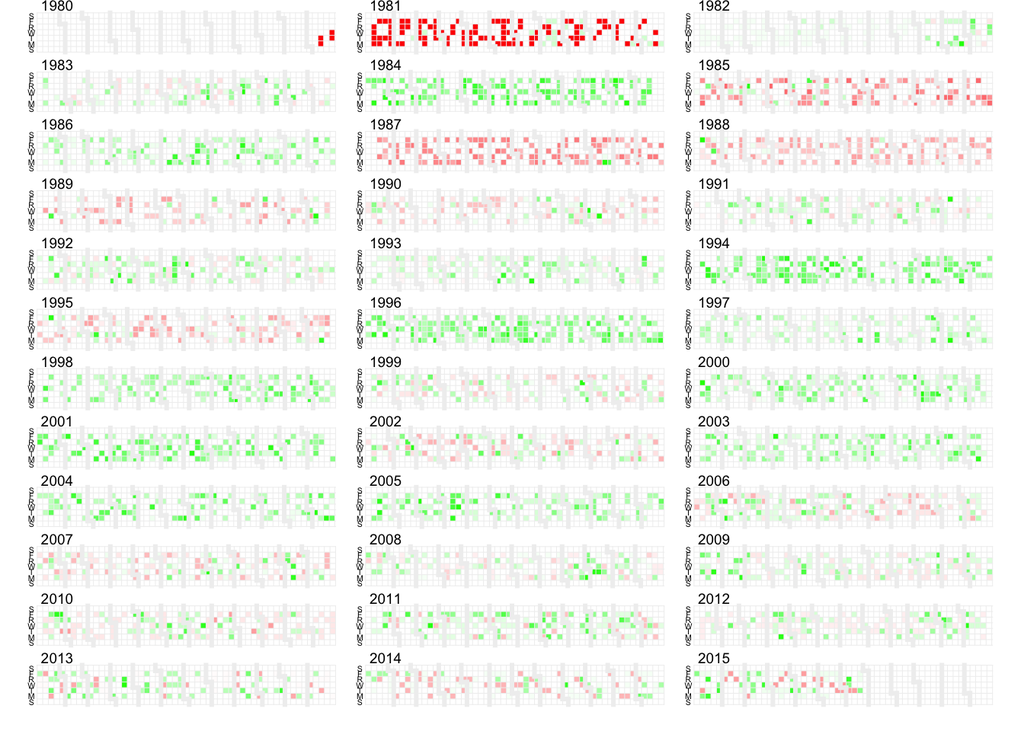

```r
source('./calendarCustom.R')

plotSingle <- function(yr, df) {
  dfsubset <- subset(df, year(date) == yr)
  calendarFlow(dfsubset$date, dfsubset$Change_pct, palette="redgreen", main=toString(yr))
}

years <- seq(1980, 2015, 1)
par(mfrow = c(12, 3), oma=c(1, 1, 0, 1), mar=c(0, 0, 0, 0))
invisible(sapply(years, plotSingle, df=dfnew))
```